# Libraries

```r
library(tidyverse)
library(knitr)
library(ggplot2)
library(here)
library(readr)
library(dplyr)
library(tidyr)
```

## 2.1 Dataset Overview

```r
access_healthcare <- read.csv("access-to-health-care_national_zaf.csv")
maternal_mortality <- read.csv( "maternal-mortality_national_zaf.csv")
immunization <- read.csv( "immunization_national_zaf.csv")
child_mortality <- read.csv ("child-mortality-rates_national_zaf.csv")

access_healthcare <- access_healthcare[-1, ]
child_mortality <- child_mortality[-1, ]
immunization <- immunization[-1, ]
maternal_mortality <- maternal_mortality[-1, ]
```

#Chnages data types

```r
#Changing Data types

#Convert value to numeric
access_healthcare$Value <- as.numeric(access_healthcare$Value)
child_mortality$Value <- as.numeric(child_mortality$Value)
immunization$Value <- as.numeric(immunization$Value)
maternal_mortality$Value <- as.numeric(maternal_mortality$Value)

#Convert Precision to numeric
access_healthcare$Precision  <- as.numeric(access_healthcare$Precision )
child_mortality$Precision  <- as.numeric(child_mortality$Precision )
immunization$Precision  <- as.numeric(immunization$Precision )
maternal_mortality$Precision  <- as.numeric(maternal_mortality$Precision )

#Convert CharacteristicId  to numeric
access_healthcare$CharacteristicId <- as.character(as.numeric(access_healthcare$CharacteristicId))
child_mortality$CharacteristicId <- as.character(as.numeric(child_mortality$CharacteristicId))
immunization$CharacteristicId <- as.character(as.numeric(immunization$CharacteristicId))
maternal_mortality$CharacteristicId <- as.character(as.numeric(maternal_mortality$CharacteristicId))

# Convert SurveyYear to numeric for plots
access_healthcare$SurveyYear <- as.numeric(access_healthcare$SurveyYear)
child_mortality$SurveyYear <- as.numeric(child_mortality$SurveyYear)
immunization$SurveyYear <- as.numeric(immunization$SurveyYear)
maternal_mortality$SurveyYear <- as.numeric(maternal_mortality$SurveyYear)

# Dropping Column RegionalId no values

access_healthcare$RegionId <- NULL
child_mortality$RegionId <- NULL
immunization$RegionId <- NULL
maternal_mortality$RegionId <- NULL

# Dropping Column RegionalId suplicate values
access_healthcare$SurveyYearLabel <- NULL
child_mortality$SurveyYearLabel<- NULL
immunization$SurveyYearLabel <- NULL
maternal_mortality$SurveyYearLabel <- NULL

# Dropping Column levelRank no values
access_healthcare$LevelRank <- NULL
child_mortality$LevelRank<- NULL
immunization$LevelRank <- NULL
maternal_mortality$LevelRank <- NULL
```

#FIlling missing values

```r
child_mortality$ByVariableLabel[child_mortality$ByVariableLabel == "" | is.na(child_mortality$ByVariableLabel)] <- "Unknown"
maternal_mortality$ByVariableLabel[maternal_mortality$ByVariableLabel == "" | is.na(maternal_mortality$ByVariableLabel)] <- "Unknown"
```

#Structure of datasets

```r
str(access_healthcare)
```

```
## 'data.frame':    275 obs. of  26 variables:
##  $ ISO3                  : chr  "ZAF" "ZAF" "ZAF" "ZAF" ...
##  $ DataId                : chr  "751751" "567476" "205488" "751748" ...
##  $ Indicator             : chr  "Antenatal care provider: Doctor" "Antenatal care provider: Doctor" "Antenatal care provider: Doctor" "Antenatal care provider: Nurse/midwife" ...
##  $ Value                 : num  28.5 30 27.3 66.6 65 68.4 0.1 0.1 0.1 0.6 ...
##  $ Precision             : num  1 1 1 1 1 1 1 1 1 1 ...
##  $ DHS_CountryCode       : chr  "ZA" "ZA" "ZA" "ZA" ...
##  $ CountryName           : chr  "South Africa" "South Africa" "South Africa" "South Africa" ...
##  $ SurveyYear            : num  1998 1998 1998 1998 1998 ...
##  $ SurveyId              : chr  "ZA1998DHS" "ZA1998DHS" "ZA1998DHS" "ZA1998DHS" ...
##  $ IndicatorId           : chr  "RH_ANCP_W_DOC" "RH_ANCP_W_DOC" "RH_ANCP_W_DOC" "RH_ANCP_W_NRS" ...
##  $ IndicatorOrder        : int  83363010 83363010 83363010 83363020 83363020 83363020 83363070 83363070 83363070 83363080 ...
##  $ IndicatorType         : chr  "I" "I" "I" "I" ...
##  $ CharacteristicId      : chr  "1000" "1000" "1000" "1000" ...
##  $ CharacteristicOrder   : int  0 0 0 0 0 0 0 0 0 0 ...
##  $ CharacteristicCategory: chr  "Total" "Total" "Total" "Total" ...
##  $ CharacteristicLabel   : chr  "Total" "Total" "Total" "Total" ...
##  $ ByVariableId          : chr  "14000" "14001" "14002" "14000" ...
##  $ ByVariableLabel       : chr  "Three years preceding the survey" "Five years preceding the survey" "Two years preceding the survey" "Three years preceding the survey" ...
##  $ IsTotal               : int  1 1 1 1 1 1 1 1 1 1 ...
##  $ IsPreferred           : int  0 0 1 0 0 1 0 0 1 0 ...
##  $ SDRID                 : chr  "RHANCPWDOC" "RHANCPWDOC" "RHANCPWDOC" "RHANCPWNRS" ...
##  $ SurveyType            : chr  "DHS" "DHS" "DHS" "DHS" ...
##  $ DenominatorWeighted   : int  2871 4122 2010 2871 4122 2010 2871 4122 2010 2871 ...
##  $ DenominatorUnweighted : int  2903 4148 2041 2903 4148 2041 2903 4148 2041 2903 ...
##  $ CILow                 : logi  NA NA NA NA NA NA ...
##  $ CIHigh                : logi  NA NA NA NA NA NA ...
```

```r
str(child_mortality)
```

```
## 'data.frame':    40 obs. of  26 variables:
##  $ ISO3                  : chr  "ZAF" "ZAF" "ZAF" "ZAF" ...
##  $ DataId                : chr  "85995" "794581" "785930" "56239" ...
##  $ Indicator             : chr  "Neonatal mortality rate (5 year periods)" "Postneonatal mortality (5 year periods)" "Infant mortality rate (5 year periods)" "Child mortality (5 year periods)" ...
##  $ Value                 : num  20 26 45 15 59 20 19 26 23 45 ...
##  $ Precision             : num  0 0 0 0 0 0 0 0 0 0 ...
##  $ DHS_CountryCode       : chr  "ZA" "ZA" "ZA" "ZA" ...
##  $ CountryName           : chr  "South Africa" "South Africa" "South Africa" "South Africa" ...
##  $ SurveyYear            : num  1998 1998 1998 1998 1998 ...
##  $ SurveyId              : chr  "ZA1998DHS" "ZA1998DHS" "ZA1998DHS" "ZA1998DHS" ...
##  $ IndicatorId           : chr  "CM_ECMT_C_NNR" "CM_ECMT_C_PNR" "CM_ECMT_C_IMR" "CM_ECMT_C_CMR" ...
##  $ IndicatorOrder        : int  63166010 63166020 63166030 63166040 63166050 63206010 63206010 63206020 63206020 63206030 ...
##  $ IndicatorType         : chr  "I" "I" "I" "I" ...
##  $ CharacteristicId      : chr  "13000" "13000" "13000" "13000" ...
##  $ CharacteristicOrder   : int  80000 80000 80000 80000 80000 0 0 0 0 0 ...
##  $ CharacteristicCategory: chr  "Five year periods" "Five year periods" "Five year periods" "Five year periods" ...
##  $ CharacteristicLabel   : chr  "0-4" "0-4" "0-4" "0-4" ...
##  $ ByVariableId          : chr  "0" "0" "0" "0" ...
##  $ ByVariableLabel       : chr  "Unknown" "Unknown" "Unknown" "Unknown" ...
##  $ IsTotal               : int  1 1 1 1 1 1 1 1 1 1 ...
##  $ IsPreferred           : int  1 1 1 1 1 1 0 1 0 1 ...
##  $ SDRID                 : chr  "CMECMTCNNR" "CMECMTCPNR" "CMECMTCIMR" "CMECMTCCMR" ...
##  $ SurveyType            : chr  "DHS" "DHS" "DHS" "DHS" ...
##  $ DenominatorWeighted   : int  NA NA NA NA NA NA NA NA NA NA ...
##  $ DenominatorUnweighted : int  NA NA NA NA NA NA NA NA NA NA ...
##  $ CILow                 : int  15 20 38 9 50 15 16 20 19 38 ...
##  $ CIHigh                : int  25 31 53 20 68 25 23 31 27 53 ...
```

```r
str(immunization)
```

```
## 'data.frame':    116 obs. of  26 variables:
##  $ ISO3                  : chr  "ZAF" "ZAF" "ZAF" "ZAF" ...
##  $ DataId                : chr  "330965" "139796" "330966" "139797" ...
##  $ Indicator             : chr  "BCG vaccination received" "BCG vaccination received" "DPT 1 vaccination received" "DPT 1 vaccination received" ...
##  $ Value                 : num  96.8 94.9 93.3 93.1 86.2 82.4 76.4 73.8 91.2 87.7 ...
##  $ Precision             : num  1 1 1 1 1 1 1 1 1 1 ...
##  $ DHS_CountryCode       : chr  "ZA" "ZA" "ZA" "ZA" ...
##  $ CountryName           : chr  "South Africa" "South Africa" "South Africa" "South Africa" ...
##  $ SurveyYear            : num  1998 1998 1998 1998 1998 ...
##  $ SurveyId              : chr  "ZA1998DHS" "ZA1998DHS" "ZA1998DHS" "ZA1998DHS" ...
##  $ IndicatorId           : chr  "CH_VACS_C_BCG" "CH_VACS_C_BCG" "CH_VACS_C_DP1" "CH_VACS_C_DP1" ...
##  $ IndicatorOrder        : int  93886010 93886010 93886020 93886020 93886030 93886030 93886040 93886040 93886050 93886050 ...
##  $ IndicatorType         : chr  "I" "I" "I" "I" ...
##  $ CharacteristicId      : chr  "268002" "268002" "268002" "268002" ...
##  $ CharacteristicOrder   : int  268002 268002 268002 268002 268002 268002 268002 268002 268002 268002 ...
##  $ CharacteristicCategory: chr  "Source of vaccination information" "Source of vaccination information" "Source of vaccination information" "Source of vaccination information" ...
##  $ CharacteristicLabel   : chr  "Either source" "Either source" "Either source" "Either source" ...
##  $ ByVariableId          : chr  "258001" "258002" "258001" "258002" ...
##  $ ByVariableLabel       : chr  "12-23" "24-35" "12-23" "24-35" ...
##  $ IsTotal               : int  1 1 1 1 1 1 1 1 1 1 ...
##  $ IsPreferred           : int  1 0 1 0 1 0 1 0 1 0 ...
##  $ SDRID                 : chr  "CHVACSCBCG" "CHVACSCBCG" "CHVACSCDP1" "CHVACSCDP1" ...
##  $ SurveyType            : chr  "DHS" "DHS" "DHS" "DHS" ...
##  $ DenominatorWeighted   : int  973 933 973 933 973 933 973 933 973 933 ...
##  $ DenominatorUnweighted : int  971 951 971 951 971 951 971 951 971 951 ...
##  $ CILow                 : logi  NA NA NA NA NA NA ...
##  $ CIHigh                : logi  NA NA NA NA NA NA ...
```

```r
str(maternal_mortality)
```

```
## 'data.frame':    21 obs. of  26 variables:
##  $ ISO3                  : chr  "ZAF" "ZAF" "ZAF" "ZAF" ...
##  $ DataId                : chr  "91409" "91377" "768646" "768647" ...
##  $ Indicator             : chr  "Female deaths that are pregnancy-related" "Number of pregnancy-related deaths" "Years of exposure to the risk of mortality for women" "Years of exposure to the risk of mortality for women (unweighted)" ...
##  $ Value                 : num  5.50 1.90e+01 1.23e+05 1.24e+05 1.50e-01 ...
##  $ Precision             : num  1 0 0 0 2 0 0 0 0 3 ...
##  $ DHS_CountryCode       : chr  "ZA" "ZA" "ZA" "ZA" ...
##  $ CountryName           : chr  "South Africa" "South Africa" "South Africa" "South Africa" ...
##  $ SurveyYear            : num  1998 1998 1998 1998 1998 ...
##  $ SurveyId              : chr  "ZA1998DHS" "ZA1998DHS" "ZA1998DHS" "ZA1998DHS" ...
##  $ IndicatorId           : chr  "MM_MMRT_W_FDP" "MM_MMRT_W_PDT" "MM_MMRT_W_EXP" "MM_MMRT_W_EXU" ...
##  $ IndicatorOrder        : int  77003010 77003020 77003030 77003040 77003050 77033010 77033020 77033030 77033040 77033050 ...
##  $ IndicatorType         : chr  "I" "N" "D" "U" ...
##  $ CharacteristicId      : chr  "10000" "10000" "10000" "10000" ...
##  $ CharacteristicOrder   : int  10000 10000 10000 10000 10000 0 0 0 0 0 ...
##  $ CharacteristicCategory: chr  "Total 15-49" "Total 15-49" "Total 15-49" "Total 15-49" ...
##  $ CharacteristicLabel   : chr  "Total 15-49" "Total 15-49" "Total 15-49" "Total 15-49" ...
##  $ ByVariableId          : chr  "0" "0" "0" "0" ...
##  $ ByVariableLabel       : chr  "Unknown" "Unknown" "Unknown" "Unknown" ...
##  $ IsTotal               : int  1 1 1 1 1 1 1 1 1 1 ...
##  $ IsPreferred           : int  1 1 1 1 1 1 1 1 1 1 ...
##  $ SDRID                 : chr  "MMMMRTWFDP" "MMMMRTWPDT" "MMMMRTWEXP" "MMMMRTWEXU" ...
##  $ SurveyType            : chr  "DHS" "DHS" "DHS" "DHS" ...
##  $ DenominatorWeighted   : int  NA NA NA NA 122701 NA NA NA NA NA ...
##  $ DenominatorUnweighted : int  NA NA 123738 123738 123738 NA NA NA NA NA ...
##  $ CILow                 : int  NA NA NA NA NA NA 77 NA NA NA ...
##  $ CIHigh                : int  NA NA NA NA NA NA 223 NA NA NA ...
```

#Opens up view

```r
view(access_healthcare)
view(maternal_mortality)
view(immunization)
view(child_mortality)
```

#Sum of verious data

```r
print('summary of Health care value')
```

```
## [1] "summary of Health care value"
```

```r
summary(access_healthcare$Value)
```

```
##    Min. 1st Qu.  Median    Mean 3rd Qu.    Max.
##     0.0     7.6    67.6   542.7   100.0  5066.0
```

```r
print('summary of Child Mortality value')
```

```
## [1] "summary of Child Mortality value"
```

```r
summary(child_mortality$Value)
```

```
##    Min. 1st Qu.  Median    Mean 3rd Qu.    Max.
##    7.00   19.75   35.00  466.85   52.50 5183.00
```

```r
print('summary of immunization value')
```

```
## [1] "summary of immunization value"
```

```r
summary(immunization$Value)
```

```
##    Min. 1st Qu.  Median    Mean 3rd Qu.    Max.
##    2.20   65.60   82.55  234.95   91.25 3761.00
```

```r
print('summary of  maternal mortality value')
```

```
## [1] "summary of  maternal mortality value"
```

```r
summary(maternal_mortality$Value)
```

```
##     Min.  1st Qu.   Median     Mean  3rd Qu.     Max.
##      0.0      7.8     97.0  17881.5    536.0 123738.0
```

```r
print('Missing Values')
```

```
## [1] "Missing Values"
```

```r
sum(is.na(access_healthcare))
```

```
## [1] 618
```

```r
sum(is.na(child_mortality))
```

```
## [1] 92
```

```r
sum(is.na(immunization))
```

```
## [1] 248
```

```r
sum(is.na(maternal_mortality))
```

```
## [1] 70
```

```r
print('Duplicate values')
```

```
## [1] "Duplicate values"
```

```r
sum(duplicated(access_healthcare))
```

```
## [1] 0
```

```r
sum(duplicated(child_mortality))
```

```
## [1] 0
```

```r
sum(duplicated(immunization))
```

```
## [1] 0
```

```r
sum(duplicated(maternal_mortality))
```

```
## [1] 0
```

#Visuals of data

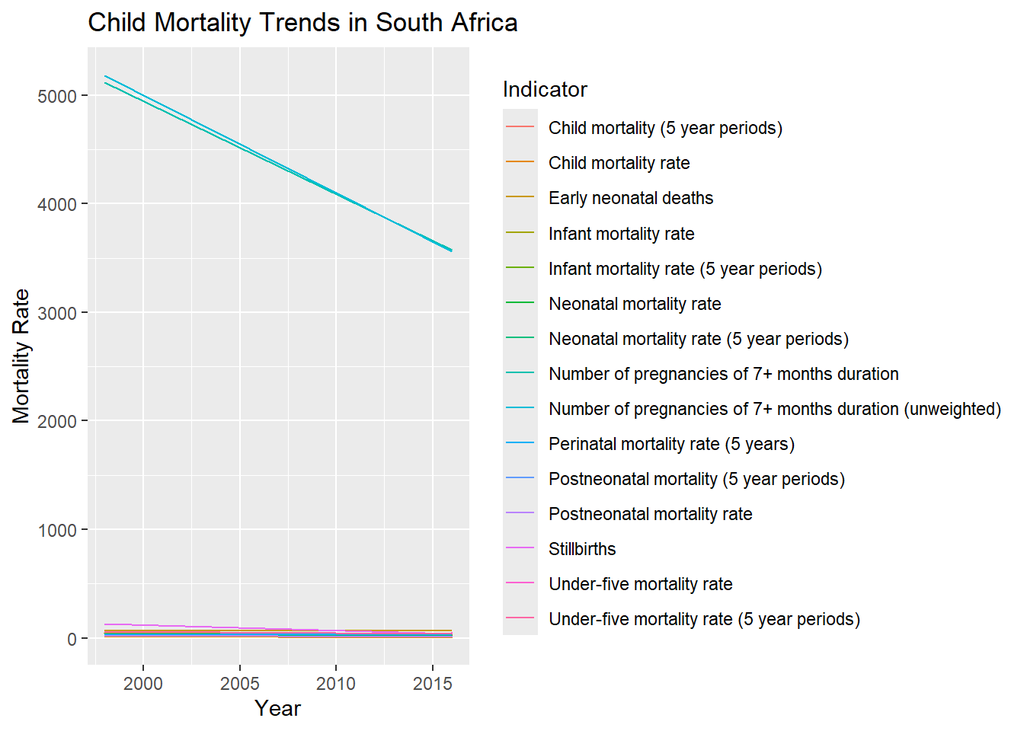

```r
# Plot child mortality over time
ggplot(child_mortality, aes(x = SurveyYear, y = as.numeric(Value), color = Indicator)) +
  geom_line() +
  labs(title = "Child Mortality Trends in South Africa", x = "Year", y = "Mortality Rate")
```

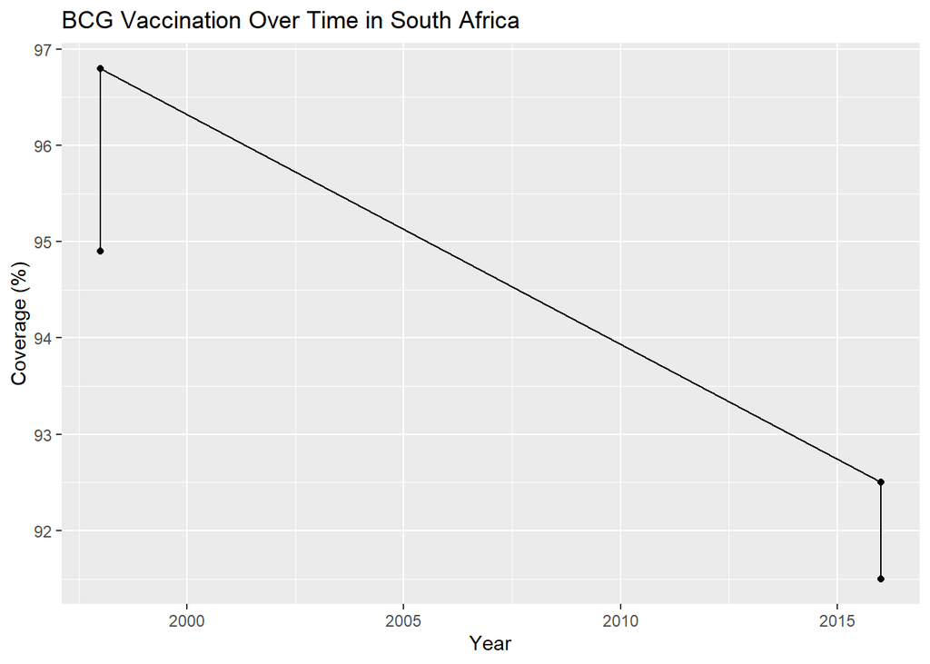

```r
# Line chart of BCG vaccination over time
ggplot(filter(immunization, Indicator == "BCG vaccination received"),
       aes(x = SurveyYear, y = Value)) +
  geom_line() +
  geom_point() +
  labs(title = "BCG Vaccination Over Time in South Africa",
       x = "Year", y = "Coverage (%)")
```

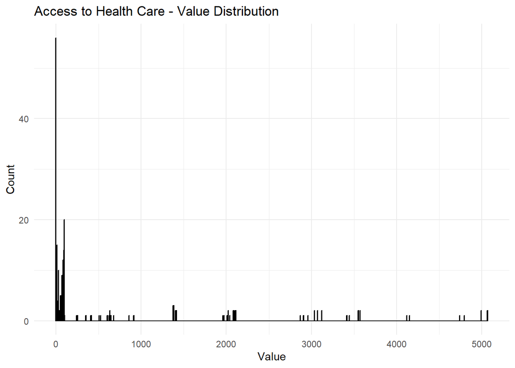

```r
#Access to Health Care - Value Distribution
ggplot(access_healthcare, aes(x = Value)) +
  geom_histogram(binwidth = 5, fill = "skyblue", color = "black") +
  labs(title = "Access to Health Care - Value Distribution", x = "Value", y = "Count") +
  theme_minimal()
```

##(Data selection and Test start) ##Ensure Value and SurveyYear are numeric

```r
access_healthcare$Value <- as.numeric(as.character(access_healthcare$Value))
child_mortality$Value <- as.numeric(as.character(child_mortality$Value))
maternal_mortality$Value <- as.numeric(as.character(maternal_mortality$Value))
immunization$Value <- as.numeric(as.character(immunization$Value))

access_healthcare$SurveyYear <- as.numeric(as.character(access_healthcare$SurveyYear))
child_mortality$SurveyYear <- as.numeric(as.character(child_mortality$SurveyYear))
maternal_mortality$SurveyYear <- as.numeric(as.character(maternal_mortality$SurveyYear))
immunization$SurveyYear <- as.numeric(as.character(immunization$SurveyYear))
```

##Structure summaries

```r
str(access_healthcare)
```

```
## 'data.frame':    275 obs. of  26 variables:
##  $ ISO3                  : chr  "ZAF" "ZAF" "ZAF" "ZAF" ...
##  $ DataId                : chr  "751751" "567476" "205488" "751748" ...
##  $ Indicator             : chr  "Antenatal care provider: Doctor" "Antenatal care provider: Doctor" "Antenatal care provider: Doctor" "Antenatal care provider: Nurse/midwife" ...
##  $ Value                 : num  28.5 30 27.3 66.6 65 68.4 0.1 0.1 0.1 0.6 ...
##  $ Precision             : num  1 1 1 1 1 1 1 1 1 1 ...
##  $ DHS_CountryCode       : chr  "ZA" "ZA" "ZA" "ZA" ...
##  $ CountryName           : chr  "South Africa" "South Africa" "South Africa" "South Africa" ...
##  $ SurveyYear            : num  1998 1998 1998 1998 1998 ...
##  $ SurveyId              : chr  "ZA1998DHS" "ZA1998DHS" "ZA1998DHS" "ZA1998DHS" ...
##  $ IndicatorId           : chr  "RH_ANCP_W_DOC" "RH_ANCP_W_DOC" "RH_ANCP_W_DOC" "RH_ANCP_W_NRS" ...
##  $ IndicatorOrder        : int  83363010 83363010 83363010 83363020 83363020 83363020 83363070 83363070 83363070 83363080 ...
##  $ IndicatorType         : chr  "I" "I" "I" "I" ...
##  $ CharacteristicId      : chr  "1000" "1000" "1000" "1000" ...
##  $ CharacteristicOrder   : int  0 0 0 0 0 0 0 0 0 0 ...
##  $ CharacteristicCategory: chr  "Total" "Total" "Total" "Total" ...
##  $ CharacteristicLabel   : chr  "Total" "Total" "Total" "Total" ...
##  $ ByVariableId          : chr  "14000" "14001" "14002" "14000" ...
##  $ ByVariableLabel       : chr  "Three years preceding the survey" "Five years preceding the survey" "Two years preceding the survey" "Three years preceding the survey" ...
##  $ IsTotal               : int  1 1 1 1 1 1 1 1 1 1 ...
##  $ IsPreferred           : int  0 0 1 0 0 1 0 0 1 0 ...
##  $ SDRID                 : chr  "RHANCPWDOC" "RHANCPWDOC" "RHANCPWDOC" "RHANCPWNRS" ...
##  $ SurveyType            : chr  "DHS" "DHS" "DHS" "DHS" ...
##  $ DenominatorWeighted   : int  2871 4122 2010 2871 4122 2010 2871 4122 2010 2871 ...
##  $ DenominatorUnweighted : int  2903 4148 2041 2903 4148 2041 2903 4148 2041 2903 ...
##  $ CILow                 : logi  NA NA NA NA NA NA ...
##  $ CIHigh                : logi  NA NA NA NA NA NA ...
```

```r
str(child_mortality)
```

```
## 'data.frame':    40 obs. of  26 variables:
##  $ ISO3                  : chr  "ZAF" "ZAF" "ZAF" "ZAF" ...
##  $ DataId                : chr  "85995" "794581" "785930" "56239" ...
##  $ Indicator             : chr  "Neonatal mortality rate (5 year periods)" "Postneonatal mortality (5 year periods)" "Infant mortality rate (5 year periods)" "Child mortality (5 year periods)" ...
##  $ Value                 : num  20 26 45 15 59 20 19 26 23 45 ...
##  $ Precision             : num  0 0 0 0 0 0 0 0 0 0 ...
##  $ DHS_CountryCode       : chr  "ZA" "ZA" "ZA" "ZA" ...
##  $ CountryName           : chr  "South Africa" "South Africa" "South Africa" "South Africa" ...
##  $ SurveyYear            : num  1998 1998 1998 1998 1998 ...
##  $ SurveyId              : chr  "ZA1998DHS" "ZA1998DHS" "ZA1998DHS" "ZA1998DHS" ...
##  $ IndicatorId           : chr  "CM_ECMT_C_NNR" "CM_ECMT_C_PNR" "CM_ECMT_C_IMR" "CM_ECMT_C_CMR" ...
##  $ IndicatorOrder        : int  63166010 63166020 63166030 63166040 63166050 63206010 63206010 63206020 63206020 63206030 ...
##  $ IndicatorType         : chr  "I" "I" "I" "I" ...
##  $ CharacteristicId      : chr  "13000" "13000" "13000" "13000" ...
##  $ CharacteristicOrder   : int  80000 80000 80000 80000 80000 0 0 0 0 0 ...
##  $ CharacteristicCategory: chr  "Five year periods" "Five year periods" "Five year periods" "Five year periods" ...
##  $ CharacteristicLabel   : chr  "0-4" "0-4" "0-4" "0-4" ...
##  $ ByVariableId          : chr  "0" "0" "0" "0" ...
##  $ ByVariableLabel       : chr  "Unknown" "Unknown" "Unknown" "Unknown" ...
##  $ IsTotal               : int  1 1 1 1 1 1 1 1 1 1 ...
##  $ IsPreferred           : int  1 1 1 1 1 1 0 1 0 1 ...
##  $ SDRID                 : chr  "CMECMTCNNR" "CMECMTCPNR" "CMECMTCIMR" "CMECMTCCMR" ...
##  $ SurveyType            : chr  "DHS" "DHS" "DHS" "DHS" ...
##  $ DenominatorWeighted   : int  NA NA NA NA NA NA NA NA NA NA ...
##  $ DenominatorUnweighted : int  NA NA NA NA NA NA NA NA NA NA ...
##  $ CILow                 : int  15 20 38 9 50 15 16 20 19 38 ...
##  $ CIHigh                : int  25 31 53 20 68 25 23 31 27 53 ...
```

```r
str(maternal_mortality)
```

```
## 'data.frame':    21 obs. of  26 variables:
##  $ ISO3                  : chr  "ZAF" "ZAF" "ZAF" "ZAF" ...
##  $ DataId                : chr  "91409" "91377" "768646" "768647" ...
##  $ Indicator             : chr  "Female deaths that are pregnancy-related" "Number of pregnancy-related deaths" "Years of exposure to the risk of mortality for women" "Years of exposure to the risk of mortality for women (unweighted)" ...
##  $ Value                 : num  5.50 1.90e+01 1.23e+05 1.24e+05 1.50e-01 ...
##  $ Precision             : num  1 0 0 0 2 0 0 0 0 3 ...
##  $ DHS_CountryCode       : chr  "ZA" "ZA" "ZA" "ZA" ...
##  $ CountryName           : chr  "South Africa" "South Africa" "South Africa" "South Africa" ...
##  $ SurveyYear            : num  1998 1998 1998 1998 1998 ...
##  $ SurveyId              : chr  "ZA1998DHS" "ZA1998DHS" "ZA1998DHS" "ZA1998DHS" ...
##  $ IndicatorId           : chr  "MM_MMRT_W_FDP" "MM_MMRT_W_PDT" "MM_MMRT_W_EXP" "MM_MMRT_W_EXU" ...
##  $ IndicatorOrder        : int  77003010 77003020 77003030 77003040 77003050 77033010 77033020 77033030 77033040 77033050 ...
##  $ IndicatorType         : chr  "I" "N" "D" "U" ...
##  $ CharacteristicId      : chr  "10000" "10000" "10000" "10000" ...
##  $ CharacteristicOrder   : int  10000 10000 10000 10000 10000 0 0 0 0 0 ...
##  $ CharacteristicCategory: chr  "Total 15-49" "Total 15-49" "Total 15-49" "Total 15-49" ...
##  $ CharacteristicLabel   : chr  "Total 15-49" "Total 15-49" "Total 15-49" "Total 15-49" ...
##  $ ByVariableId          : chr  "0" "0" "0" "0" ...
##  $ ByVariableLabel       : chr  "Unknown" "Unknown" "Unknown" "Unknown" ...
##  $ IsTotal               : int  1 1 1 1 1 1 1 1 1 1 ...
##  $ IsPreferred           : int  1 1 1 1 1 1 1 1 1 1 ...
##  $ SDRID                 : chr  "MMMMRTWFDP" "MMMMRTWPDT" "MMMMRTWEXP" "MMMMRTWEXU" ...
##  $ SurveyType            : chr  "DHS" "DHS" "DHS" "DHS" ...
##  $ DenominatorWeighted   : int  NA NA NA NA 122701 NA NA NA NA NA ...
##  $ DenominatorUnweighted : int  NA NA 123738 123738 123738 NA NA NA NA NA ...
##  $ CILow                 : int  NA NA NA NA NA NA 77 NA NA NA ...
##  $ CIHigh                : int  NA NA NA NA NA NA 223 NA NA NA ...
```

```r
str(immunization)
```

```
## 'data.frame':    116 obs. of  26 variables:
##  $ ISO3                  : chr  "ZAF" "ZAF" "ZAF" "ZAF" ...
##  $ DataId                : chr  "330965" "139796" "330966" "139797" ...
##  $ Indicator             : chr  "BCG vaccination received" "BCG vaccination received" "DPT 1 vaccination received" "DPT 1 vaccination received" ...
##  $ Value                 : num  96.8 94.9 93.3 93.1 86.2 82.4 76.4 73.8 91.2 87.7 ...
##  $ Precision             : num  1 1 1 1 1 1 1 1 1 1 ...
##  $ DHS_CountryCode       : chr  "ZA" "ZA" "ZA" "ZA" ...
##  $ CountryName           : chr  "South Africa" "South Africa" "South Africa" "South Africa" ...
##  $ SurveyYear            : num  1998 1998 1998 1998 1998 ...
##  $ SurveyId              : chr  "ZA1998DHS" "ZA1998DHS" "ZA1998DHS" "ZA1998DHS" ...
##  $ IndicatorId           : chr  "CH_VACS_C_BCG" "CH_VACS_C_BCG" "CH_VACS_C_DP1" "CH_VACS_C_DP1" ...
##  $ IndicatorOrder        : int  93886010 93886010 93886020 93886020 93886030 93886030 93886040 93886040 93886050 93886050 ...
##  $ IndicatorType         : chr  "I" "I" "I" "I" ...
##  $ CharacteristicId      : chr  "268002" "268002" "268002" "268002" ...
##  $ CharacteristicOrder   : int  268002 268002 268002 268002 268002 268002 268002 268002 268002 268002 ...
##  $ CharacteristicCategory: chr  "Source of vaccination information" "Source of vaccination information" "Source of vaccination information" "Source of vaccination information" ...
##  $ CharacteristicLabel   : chr  "Either source" "Either source" "Either source" "Either source" ...
##  $ ByVariableId          : chr  "258001" "258002" "258001" "258002" ...
##  $ ByVariableLabel       : chr  "12-23" "24-35" "12-23" "24-35" ...
##  $ IsTotal               : int  1 1 1 1 1 1 1 1 1 1 ...
##  $ IsPreferred           : int  1 0 1 0 1 0 1 0 1 0 ...
##  $ SDRID                 : chr  "CHVACSCBCG" "CHVACSCBCG" "CHVACSCDP1" "CHVACSCDP1" ...
##  $ SurveyType            : chr  "DHS" "DHS" "DHS" "DHS" ...
##  $ DenominatorWeighted   : int  973 933 973 933 973 933 973 933 973 933 ...
##  $ DenominatorUnweighted : int  971 951 971 951 971 951 971 951 971 951 ...
##  $ CILow                 : logi  NA NA NA NA NA NA ...
##  $ CIHigh                : logi  NA NA NA NA NA NA ...
```

##Summary statistics

```r
summary(access_healthcare$Value)
```

```
##    Min. 1st Qu.  Median    Mean 3rd Qu.    Max.
##     0.0     7.6    67.6   542.7   100.0  5066.0
```

```r
summary(child_mortality$Value)
```

```
##    Min. 1st Qu.  Median    Mean 3rd Qu.    Max.
##    7.00   19.75   35.00  466.85   52.50 5183.00
```

```r
summary(maternal_mortality$Value)
```

```
##     Min.  1st Qu.   Median     Mean  3rd Qu.     Max.
##      0.0      7.8     97.0  17881.5    536.0 123738.0
```

```r
summary(immunization$Value)
```

```
##    Min. 1st Qu.  Median    Mean 3rd Qu.    Max.
##    2.20   65.60   82.55  234.95   91.25 3761.00
```

```r
summary(access_healthcare$SurveyYear)
```

```
##    Min. 1st Qu.  Median    Mean 3rd Qu.    Max.
##    1998    1998    2016    2008    2016    2016
```

```r
summary(child_mortality$SurveyYear)
```

```
##    Min. 1st Qu.  Median    Mean 3rd Qu.    Max.
##    1998    1998    2007    2007    2016    2016
```

```r
summary(maternal_mortality$SurveyYear)
```

```
##    Min. 1st Qu.  Median    Mean 3rd Qu.    Max.
##    1998    1998    2016    2007    2016    2016
```

```r
summary(immunization$SurveyYear)
```

```
##    Min. 1st Qu.  Median    Mean 3rd Qu.    Max.
##    1998    1998    2016    2008    2016    2016
```

##Missing values

```r
cat("Missing Values in Value:\nAccess to Healthcare:", sum(is.na(access_healthcare$Value)),
    "\nChild Mortality:", sum(is.na(child_mortality$Value)),
    "\nMaternal Mortality:", sum(is.na(maternal_mortality$Value)),
    "\nImmunization:", sum(is.na(immunization$Value)), "\n")
```

```
## Missing Values in Value:
## Access to Healthcare: 0
## Child Mortality: 0
## Maternal Mortality: 0
## Immunization: 0
```

[output not shown]

[output not shown]

## t-test: Access to healthcare (1998 vs. 2016)

```r
group1_access <- access_healthcare %>%
  filter(SurveyYear == 1998 & !is.na(Value)) %>%
  pull(Value)

group2_access <- access_healthcare %>%
  filter(SurveyYear == 2016 & !is.na(Value)) %>%
  pull(Value)

if (length(group1_access) > 0 && length(group2_access) > 0) {
  t_test_access <- t.test(group1_access, group2_access)
  print(t_test_access)
} else {
  cat("Not enough valid data for t-test on access to healthcare.\n")
}
```

```
##
##  Welch Two Sample t-test
##
## data:  group1_access and group2_access
## t = 1.4741, df = 217.13, p-value = 0.1419
## alternative hypothesis: true difference in means is not equal to 0
## 95 percent confidence interval:
##  -69.48121 481.72552
## sample estimates:
## mean of x mean of y
##  652.8398  446.7177
```

## 1 (Data selection and test end)

## Attribute/ Feature Selection

## Introduction

This report analyses the datasets provided for BIN371 Project Milestone 2 with the aim of assessing feature usability for modelling and uncovering meaningful health-related patterns. The project investigates the link between healthcare access and maternal and child health outcomes in South Africa, using publicly available national-level data. The overall objective is to provide evidence-based insights that support better decision-making in public health policy and service delivery.

To support these goals, the report evaluates four key datasets: Access to Health Care, Child Mortality, Maternal Mortality, and Immunization. These datasets, which span surveys conducted between 1998 and 2016, include indicators such as place of delivery, type of birth assistance, immunisation rates, and mortality statistics. The CRISP-DM methodology is used as a structured framework for analysis, starting with business understanding and data exploration before moving into modelling and evaluation.

## Load datasets

```r
immunization <- read.csv("immunization_national_zaf.csv")
maternal_mortality <- read.csv("maternal-mortality_national_zaf.csv")
access_healthcare <- read.csv("access-to-health-care_national_zaf.csv")
child_mortality <- read.csv("child-mortality-rates_national_zaf.csv")
```

## Finding the Missing Value Analysis

```r
missing_percentage <- function(df){
  data.frame(
    Feature = colnames(df),
    MissingPercent = colSums(is.na(df)) / nrow(df) * 100
  )
}

missing_access <- missing_percentage(access_healthcare) %>% mutate(Dataset = "Access_Healthcare")
missing_maternal <- missing_percentage(maternal_mortality) %>% mutate(Dataset = "Maternal_Mortality")
missing_immunization <- missing_percentage(immunization) %>% mutate(Dataset = "Immunization")
missing_child <- missing_percentage(child_mortality) %>% mutate(Dataset = "Child_Mortality")

missing_summary <- bind_rows(missing_access, missing_maternal, missing_immunization, missing_child)

kable(missing_summary, caption = "Percentage of Missing Values per Feature")
```

Percentage of Missing Values per Feature

|  | Feature | MissingPercent | Dataset |
| --- | --- | --- | --- |
| ISO3…1 | ISO3 | 0.0000000 | Access_Healthcare |
| DataId…2 | DataId | 0.0000000 | Access_Healthcare |
| Indicator…3 | Indicator | 0.0000000 | Access_Healthcare |
| Value…4 | Value | 0.0000000 | Access_Healthcare |
| Precision…5 | Precision | 0.0000000 | Access_Healthcare |
| DHS_CountryCode…6 | DHS_CountryCode | 0.0000000 | Access_Healthcare |
| CountryName…7 | CountryName | 0.0000000 | Access_Healthcare |
| SurveyYear…8 | SurveyYear | 0.0000000 | Access_Healthcare |
| SurveyId…9 | SurveyId | 0.0000000 | Access_Healthcare |
| IndicatorId…10 | IndicatorId | 0.0000000 | Access_Healthcare |
| IndicatorOrder…11 | IndicatorOrder | 0.3623188 | Access_Healthcare |
| IndicatorType…12 | IndicatorType | 0.0000000 | Access_Healthcare |
| CharacteristicId…13 | CharacteristicId | 0.3623188 | Access_Healthcare |
| CharacteristicOrder…14 | CharacteristicOrder | 0.3623188 | Access_Healthcare |
| CharacteristicCategory…15 | CharacteristicCategory | 0.0000000 | Access_Healthcare |
| CharacteristicLabel…16 | CharacteristicLabel | 0.0000000 | Access_Healthcare |
| ByVariableId…17 | ByVariableId | 0.0000000 | Access_Healthcare |
| ByVariableLabel…18 | ByVariableLabel | 0.0000000 | Access_Healthcare |
| IsTotal…19 | IsTotal | 0.3623188 | Access_Healthcare |
| IsPreferred…20 | IsPreferred | 0.3623188 | Access_Healthcare |
| SDRID…21 | SDRID | 0.0000000 | Access_Healthcare |
| RegionId…22 | RegionId | 100.0000000 | Access_Healthcare |
| SurveyYearLabel…23 | SurveyYearLabel | 0.3623188 | Access_Healthcare |
| SurveyType…24 | SurveyType | 0.0000000 | Access_Healthcare |
| DenominatorWeighted…25 | DenominatorWeighted | 12.6811594 | Access_Healthcare |
| DenominatorUnweighted…26 | DenominatorUnweighted | 12.6811594 | Access_Healthcare |
| CILow…27 | CILow | 100.0000000 | Access_Healthcare |
| CIHigh…28 | CIHigh | 100.0000000 | Access_Healthcare |
| LevelRank…29 | LevelRank | 100.0000000 | Access_Healthcare |
| ISO3…30 | ISO3 | 0.0000000 | Maternal_Mortality |

[output cut: 86 more lines]

## Correlation Analysis

```r
target <- "Value"
child_mortality$Value <- as.numeric(as.character(child_mortality$Value))
numeric_data <- child_mortality %>% select(where(is.numeric))
cor_results <- data.frame(
  Feature = colnames(numeric_data),
  CorrelationWithTarget = sapply(numeric_data, function(x){
    if(all(is.na(x)) || sd(x, na.rm = TRUE) == 0) return(NA)
    cor(x, numeric_data[[target]], use = "complete.obs")
  })
)

feature_summary <- left_join(missing_summary, cor_results, by="Feature") %>% mutate(
  Keep = ifelse(MissingPercent > 80 | abs(CorrelationWithTarget) < 0.1, "No", "Yes"),
  Reason = case_when(
    MissingPercent > 80 ~ "Too many missing values",
    abs(CorrelationWithTarget) < 0.1 ~ "Weak correlation",
    TRUE ~ "Relevant"
  )
)

kable(feature_summary, caption = "Feature Usability Summary")
```

Feature Usability Summary

| Feature | MissingPercent | Dataset | CorrelationWithTarget | Keep | Reason |
| --- | --- | --- | --- | --- | --- |
| ISO3 | 0.0000000 | Access_Healthcare | NA | NA | Relevant |
| DataId | 0.0000000 | Access_Healthcare | NA | NA | Relevant |
| Indicator | 0.0000000 | Access_Healthcare | NA | NA | Relevant |
| Value | 0.0000000 | Access_Healthcare | 1.0000000 | Yes | Relevant |
| Precision | 0.0000000 | Access_Healthcare | NA | NA | Relevant |
| DHS_CountryCode | 0.0000000 | Access_Healthcare | NA | NA | Relevant |
| CountryName | 0.0000000 | Access_Healthcare | NA | NA | Relevant |
| SurveyYear | 0.0000000 | Access_Healthcare | NA | NA | Relevant |
| SurveyId | 0.0000000 | Access_Healthcare | NA | NA | Relevant |
| IndicatorId | 0.0000000 | Access_Healthcare | NA | NA | Relevant |
| IndicatorOrder | 0.3623188 | Access_Healthcare | 0.4331566 | Yes | Relevant |
| IndicatorType | 0.0000000 | Access_Healthcare | NA | NA | Relevant |
| CharacteristicId | 0.3623188 | Access_Healthcare | 0.2316770 | Yes | Relevant |
| CharacteristicOrder | 0.3623188 | Access_Healthcare | -0.1240480 | Yes | Relevant |
| CharacteristicCategory | 0.0000000 | Access_Healthcare | NA | NA | Relevant |
| CharacteristicLabel | 0.0000000 | Access_Healthcare | NA | NA | Relevant |
| ByVariableId | 0.0000000 | Access_Healthcare | NA | NA | Relevant |
| ByVariableLabel | 0.0000000 | Access_Healthcare | NA | NA | Relevant |
| IsTotal | 0.3623188 | Access_Healthcare | NA | NA | Relevant |
| IsPreferred | 0.3623188 | Access_Healthcare | 0.1907488 | Yes | Relevant |
| SDRID | 0.0000000 | Access_Healthcare | NA | NA | Relevant |
| RegionId | 100.0000000 | Access_Healthcare | NA | No | Too many missing values |
| SurveyYearLabel | 0.3623188 | Access_Healthcare | -0.0636188 | No | Weak correlation |
| SurveyType | 0.0000000 | Access_Healthcare | NA | NA | Relevant |
| DenominatorWeighted | 12.6811594 | Access_Healthcare | 0.1814778 | Yes | Relevant |
| DenominatorUnweighted | 12.6811594 | Access_Healthcare | 0.1742638 | Yes | Relevant |
| CILow | 100.0000000 | Access_Healthcare | 0.9947535 | No | Too many missing values |
| CIHigh | 100.0000000 | Access_Healthcare | 0.9968934 | No | Too many missing values |
| LevelRank | 100.0000000 | Access_Healthcare | NA | No | Too many missing values |
| ISO3 | 0.0000000 | Maternal_Mortality | NA | NA | Relevant |

[output cut: 86 more lines]

## Interpretation of Feature Selection

Based on the missing values analysis and feature correlation with the target variables, we identified and removed features that are either incomplete or irrelevant for modelling. The decisions were guided by two main criteria:

High missingness: Features with over 80% missing data are considered unreliable for analysis and were removed.

Low correlation: Features with correlation below 0.1 with the target variable are unlikely to contribute meaningfully to predictive models and were excluded unless domain knowledge suggested otherwise.

## Key Decisions by Dataset

Access to Healthcare Dataset:

Removed: CILow, CIHigh, RegionId, LevelRank

Reason: These columns had 100% missing values or no meaningful data.

Retained: Features such as IndicatorOrder, CharacteristicId, and IsPreferred showed moderate correlations with the target and were kept.

Maternal Mortality Dataset:

Removed: CILow, CIHigh, RegionId, LevelRank, and DenominatorWeighted

Reason: These fields either had extremely high missingness or weak correlation with maternal mortality indicators.

Retained: Fields like IndicatorOrder, CharacteristicId, and DenominatorUnweighted were preserved due to moderate correlation and potential relevance.

Immunization Dataset:

Removed: CILow, CIHigh, RegionId, and LevelRank

Reason: All had 100% missing values, making them unusable.

Retained: Most other columns had low to moderate missingness and demonstrated relevance to the project’s goal of assessing immunization coverage.

Child Mortality Dataset:

Removed: RegionId, LevelRank, DenominatorWeighted, DenominatorUnweighted

Reason: These columns either had missing data exceeding 90% or showed minimal correlation with child mortality outcomes.

Retained: CIHigh and CILow were kept here due to strong correlation values (~0.99), despite higher missingness, indicating they may be useful when available.